# Codebook and Some Descriptives for Datasets`

# I. About `paper_titles_rus_studies.csv`

## Codebook

### Variables

`UT`: Unique Identifier for the publication.

`year`: Year of publication.

`TI`: Title of the publication.

`AU`: Surname of the author and initials.

`country`: Country of the author’s affiliation.

`research_areas`: Research areas of a journal (WOS classification). *Note*: A journal can have multiple research areas (see Table 2).

`sh_US_authors`: Share of authors with US affiliation. [from 0 to 100].

`sh_Rus_authors`: Share of authors with Russian affiliation. [from 0 to 100].

`AB`: Abstract of the publication (source: WOS).

### Data Structure

The table is in long form. For example, the publication `WOS:000233752600006` was written by seven authors. Thus, the publication has seven rows, with each author having their own row.

*Example:*

|  | UT | year | TI | AU | country | research_areas | n_authors | n_authors_rus | n_authors_us | sh_US_authors | sh_rus_authors |
| --- | --- | --- | --- | --- | --- | --- | --- | --- | --- | --- | --- |
| 1 | WOS:000233752600006 | 2005 | Impact of socio-economic factors on higher education in Russia | Markusova, VA | Russia | Education &amp; Information Science | 7 | 5 | 0 | 0 | 71.4285714285714 |
| 2 | WOS:000233752600006 | 2005 | Impact of socio-economic factors on higher education in Russia | Arapov, MV | Russia | Education &amp; Information Science | 7 | 5 | 0 | 0 | 71.4285714285714 |
| 3 | WOS:000233752600006 | 2005 | Impact of socio-economic factors on higher education in Russia | Libkind, AN | Russia | Education &amp; Information Science | 7 | 5 | 0 | 0 | 71.4285714285714 |
| 4 | WOS:000233752600006 | 2005 | Impact of socio-economic factors on higher education in Russia | Minin, VA | Russia | Education &amp; Information Science | 7 | 5 | 0 | 0 | 71.4285714285714 |
| 5 | WOS:000233752600006 | 2005 | Impact of socio-economic factors on higher education in Russia | Jansz, CNM | Russia | Education &amp; Information Science | 7 | 5 | 0 | 0 | 71.4285714285714 |
| 6 | WOS:000233752600006 | 2005 | Impact of socio-economic factors on higher education in Russia | Zitt, M | Netherlands | Education &amp; Information Science | 7 | 5 | 0 | 0 | 71.4285714285714 |
| 7 | WOS:000233752600006 | 2005 | Impact of socio-economic factors on higher education in Russia | Bassecoulard-Zitt, E | France | Education &amp; Information Science | 7 | 5 | 0 | 0 | 71.4285714285714 |

## Some Descriptives

### Table 1: Countries in the dataset (author affiliations)

Observation: author

|  | country | n |
| --- | --- | --- |
| 1 | United States | 11485 |
| 2 | Russia | 5477 |
| 3 | United Kingdom | 3954 |
| 4 | Unknown | 3765 |
| 5 | Germany | 1095 |
| 6 | Canada | 943 |
| 7 | Finland | 674 |
| 8 | Australia | 460 |
| 9 | Israel | 454 |
| 10 | Netherlands | 453 |

[output cut: 86 more lines]

### Table 2: Research areas in the dataset (WOS journal classification)

Observation: paper

|  | research_areas | n |
| --- | --- | --- |
| 1 | Political Science | 4722 |
| 2 | History | 4364 |
| 3 | Business, Economics &amp; Management | 3124 |
| 4 | Literature | 2937 |
| 5 | Art | 1827 |
| 6 | Area Studies | 1401 |
| 7 | Philosophy &amp; Religion | 1346 |
| 8 | Sociology &amp; Anthropology | 1333 |
| 9 | Multidisciplinary | 1259 |
| 10 | Language &amp; Linguistics | 786 |

[output cut: 64 more lines]

### Table 3: Abstracts availability

Observation: paper

|  | year | have | no | total | share_no_abstract_% |
| --- | --- | --- | --- | --- | --- |
| 1 | 1990 | 2 | 792 | 794 | 99.75 |
| 2 | 1991 | 33 | 829 | 862 | 96.17 |
| 3 | 1992 | 112 | 606 | 718 | 84.4 |
| 4 | 1993 | 123 | 557 | 680 | 81.91 |
| 5 | 1994 | 139 | 589 | 728 | 80.91 |
| 6 | 1995 | 184 | 552 | 736 | 75 |
| 7 | 1996 | 169 | 625 | 794 | 78.72 |
| 8 | 1997 | 180 | 518 | 698 | 74.21 |
| 9 | 1998 | 190 | 584 | 774 | 75.45 |
| 10 | 1999 | 240 | 477 | 717 | 66.53 |

[output cut: 21 more lines]

### Table 4: Varibles `sh_US_authors` and `sh_Rus_authors`

In the case of paper `WOS:000468501800005`, there are three authors: two from the US and one from Russia.

|  | UT | country | AU | n_authors | n_authors_rus | n_authors_us | sh_US_authors | sh_rus_authors |
| --- | --- | --- | --- | --- | --- | --- | --- | --- |
| 1 | WOS:000468501800005 | United States | Golub, A | 3 | 1 | 2 | 66.6666666666667 | 33.3333333333333 |
| 2 | WOS:000468501800005 | Russia | Potashnikov, V | 3 | 1 | 2 | 66.6666666666667 | 33.3333333333333 |
| 3 | WOS:000468501800005 | United States | Lugovoy, O | 3 | 1 | 2 | 66.6666666666667 | 33.3333333333333 |

# II. About `dataset_1_uniqe.csv`

### Table 5: Dataset 1. only authors from US or Russia (i.e., remove all the papers that have an author with an affiliation not in the US or Russia)

From the dataset `paper_titles_rus_studies.csv`, we created `dataset_1_uniqe.csv`, which includes 3,173 papers written ONLY by Russian authors and 8,902 papers written ONLY by US authors.

|  | sh_US_authors | sh_rus_authors | n |
| --- | --- | --- | --- |
| 1 | 0 | 100 | 3173 |
| 2 | 100 | 0 | 8902 |

### Figure 1. Abstracts availability in `dataset_1_uniqe.csv`

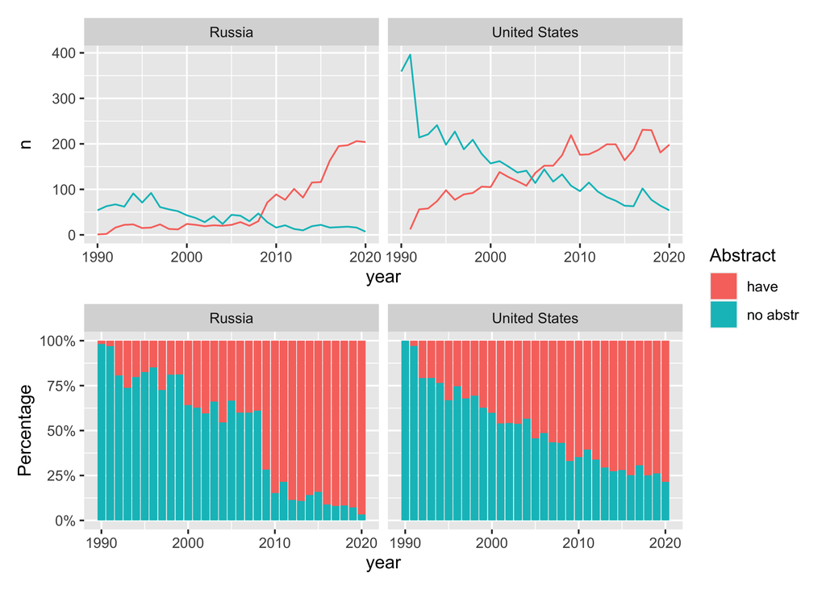